# Linear Regression

Tikam Singh

2022-01-10

```r
# Helper packages
library(dplyr)    # for data manipulation
library(ggplot2)  # for awesome graphics

# Modeling packages
library(caret)    # for cross-validation, etc.

# Model interpretability packages
library(vip)      # variable importance
library(AmesHousing)
library(rsample)
```

```r
set.seed(123)
ames <- AmesHousing::make_ames()
split <- initial_split(ames, prop = 0.7,
                       strata = "Sale_Price")
ames_train  <- training(split)
ames_test   <- testing(split)
```

### Regression (Gr_Liv_Area) and sale price

- With the Ames housing data, suppose we wanted to model a linear relationship between the total above ground living space of a home (Gr_Liv_Area) and sale price (Sale_Price). #### To perform an OLS regression model in R we can use the lm() function:

```r
model1 <- lm(Sale_Price ~ Gr_Liv_Area, data = ames_train)
summary(model1)
```

```
##
## Call:
## lm(formula = Sale_Price ~ Gr_Liv_Area, data = ames_train)
##
## Residuals:
##     Min      1Q  Median      3Q     Max
## -474682  -30794   -1678   23353  328183
##
## Coefficients:
##              Estimate Std. Error t value Pr(>|t|)
## (Intercept) 15938.173   3851.853   4.138 3.65e-05 ***
## Gr_Liv_Area   109.667      2.421  45.303  < 2e-16 ***
## ---
## Signif. codes:  0 '***' 0.001 '**' 0.01 '*' 0.05 '.' 0.1 ' ' 1
##
## Residual standard error: 56790 on 2047 degrees of freedom
## Multiple R-squared:  0.5007, Adjusted R-squared:  0.5004
## F-statistic:  2052 on 1 and 2047 DF,  p-value: < 2.2e-16
```

```r
sigma(model1)    # RMSE
```

```
## [1] 56787.94
```

```r
sigma(model1)^2  #MSE
```

```
## [1] 3224869786
```

- t value = Estimate / Std. Error The reported t-statistics measure the number of standard deviations each coefficient is away from 0.
- Thus, large t-statistics (greater than two in absolute value, say roughly indicate statistical significance at the α=0.05 level. The p-values for these tests are also reported by summary() in the column labeled Pr(>|t|). ***

#### Drawbacks Of OLS Linear Regression

- One drawback of the LS procedure in linear regression is that it only provides estimates of the coefficients; it does not provide an estimate of the error variance  
  σ^2 2.LS also makes no assumptions about the random errors.
- These assumptions are important for inference and in estimating the error variance which we’re assuming is a constant value σ^2.

Most statistical software, including R, will include estimated standard errors, t-statistics, etc. as part of its regression output. However, it is important to remember that such quantities depend on three major assumptions of the linear regression model:

> - Independent observations
> - The random errors have mean zero, and constant variance
> - The random errors are normally distributed

Assessing model accuracy

we have fited main effects models to the Ames housing data: a single predictor, But the question remains, which model is “best”? To answer this question we have to define what we mean by “best”. In our case, we’ll use the RMSE metric and cross-validation to determine the “best” model. We can use the caret::train() function to train a linear model (i.e., method = “lm”) using cross-validation (or a variety of other validation methods). In practice, a number of factors should be considered in determining a “best” model (e.g., time constraints, model production cost, predictive accuracy, etc.). The benefit of caret is that it provides built-in cross-validation capabilities, whereas the lm() function does not19. The following code chunk uses caret::train() to refit model1 using 10-fold cross-validation:

```r
# Train model using 10-fold cross-validation

set.seed(123)  # for reproducibility
    cv_model1 <- train(
                form = Sale_Price ~ Gr_Liv_Area,
                data = ames_train,
                method = "lm",
                trControl = trainControl(method = "cv", number = 10)
              )
summary(cv_model1)
```

```
##
## Call:
## lm(formula = .outcome ~ ., data = dat)
##
## Residuals:
##     Min      1Q  Median      3Q     Max
## -474682  -30794   -1678   23353  328183
##
## Coefficients:
##              Estimate Std. Error t value Pr(>|t|)
## (Intercept) 15938.173   3851.853   4.138 3.65e-05 ***
## Gr_Liv_Area   109.667      2.421  45.303  < 2e-16 ***
## ---
## Signif. codes:  0 '***' 0.001 '**' 0.01 '*' 0.05 '.' 0.1 ' ' 1
##
## Residual standard error: 56790 on 2047 degrees of freedom
## Multiple R-squared:  0.5007, Adjusted R-squared:  0.5004
## F-statistic:  2052 on 1 and 2047 DF,  p-value: < 2.2e-16
```

perform cross-validation on the other two models in a similar fashion, which we do in the code chunk below.

```r
# model 2 CV
set.seed(123)
cv_model2 <- train(
                    Sale_Price ~ Gr_Liv_Area + Year_Built,
                    data = ames_train,
                    method = "lm",
                    trControl = trainControl(method = "cv", number = 10)
                  )

# model 3 CV
set.seed(123)
cv_model3 <- train(
                    Sale_Price ~ .,
                    data = ames_train,
                    method = "lm",
                    trControl = trainControl(method = "cv", number = 10)
                  )


# Extract out of sample performance measures
summary(resamples(list(
  model1 = cv_model1,
  model2 = cv_model2,
  model3 = cv_model3
)))
```

```
##
## Call:
## summary.resamples(object = resamples(list(model1 = cv_model1, model2
##  = cv_model2, model3 = cv_model3)))
##
## Models: model1, model2, model3
## Number of resamples: 10
##
## MAE
##            Min.  1st Qu.   Median     Mean  3rd Qu.     Max. NA's
## model1 34076.73 37656.23 39785.18 38851.99 40200.92 42058.68    0
## model2 29227.14 30885.17 32003.59 31695.48 32710.41 33942.26    0
## model3 14740.86 15377.88 17564.13 17559.41 19344.23 21180.02    0
##
## RMSE
##            Min.  1st Qu.   Median     Mean  3rd Qu.     Max. NA's
## model1 45604.65 55896.58 57000.74 56644.76 59544.08 66198.59    0
## model2 37174.26 42650.00 46869.84 46865.68 51155.14 55780.47    0
## model3 20737.09 24858.60 40515.19 41691.74 55969.21 69879.47    0
##
## Rsquared
##             Min.   1st Qu.    Median      Mean   3rd Qu.      Max. NA's
## model1 0.4230788 0.4621034 0.5090642 0.5102730 0.5681246 0.5996400    0
## model2 0.5829425 0.6075293 0.6865871 0.6631008 0.6976664 0.7254572    0
## model3 0.5241423 0.6343368 0.7483874 0.7578796 0.9137443 0.9328876    0
```

Model concerns As previously stated, linear regression has been a popular modeling tool due to the ease of interpreting the coefficients. However, linear regression makes several strong assumptions that are often violated as we include more predictors in our model. Violation of these assumptions can lead to flawed interpretation of the coefficients and prediction results.

1. Linear relationship
- Linear regression assumes a linear relationship between the predictor and the response variable. However,non-linear relationships can be made linear (or near-linear) by applying transformations to the response and/or predictors.

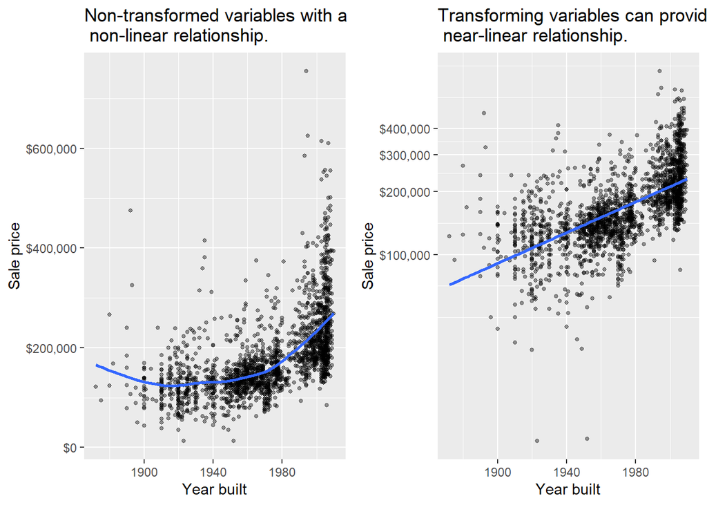

```r
p1 <- ggplot(ames_train, aes(Year_Built, Sale_Price)) +
  geom_point(size = 1, alpha = .4) +
  geom_smooth(se = FALSE) +
  scale_y_continuous("Sale price", labels = scales::dollar) +
  xlab("Year built") +
  ggtitle(paste("Non-transformed variables with a\n",
                "non-linear relationship."))

p2 <- ggplot(ames_train, aes(Year_Built, Sale_Price)) +
  geom_point(size = 1, alpha = .4) +
  geom_smooth(method = "lm", se = FALSE) +
  scale_y_log10("Sale price", labels = scales::dollar,
                breaks = seq(0, 400000, by = 100000)) +
  xlab("Year built") +
  ggtitle(paste("Transforming variables can provide a\n",
                "near-linear relationship."))

gridExtra::grid.arrange(p1, p2, nrow = 1)
```

2. Constant variance among residuals
- If the error variance is not constant, the p-values and confidence intervals for the coefficients will be invalid. Similar to the linear relationship assumption, non-constant variance can often be resolved with variable transformations or by including additional predictors.
3. No autocorrelation
- Linear regression assumes the errors are independent and uncorrelated. If in fact, there is correlation among the errors, then the estimated standard errors of the coefficients will be biased leading to prediction intervals being narrower than they should be
4. More observations than predictors
5. when the number of features exceeds the number of observations (p>np>n), the OLS estimates are not obtainable. To resolve this issue an analyst can remove variables one-at-a-time until p<np<n.
6. *Collinearity*
   - Collinearity refers to the situation in which two or more predictor variables are closely related to one another. The presence of collinearity can pose problems in the OLS, since it can be difficult to separate out the individual effects of collinear variables on the response. In fact, collinearity can cause predictor variables to appear as statistically insignificant when in fact they are significant

   ```r
   # fit with two strongly correlated variables
   summary(cv_model3) %>%
     broom::tidy() %>%
     filter(term %in% c("Garage_Area", "Garage_Cars"))
   ```

   ```
   ## # A tibble: 2 × 5
   ##   term        estimate std.error statistic p.value
   ##   <chr>          <dbl>     <dbl>     <dbl>   <dbl>
   ## 1 Garage_Cars   3151.    1733.        1.82  0.0693
   ## 2 Garage_Area     11.9      5.69      2.10  0.0359
   ```

```r
# model without Garage_Area
set.seed(123)
mod_wo_Garage_Cars <- train(
  Sale_Price ~ .,
  data = select(ames_train, -Garage_Cars),
  method = "lm",
  trControl = trainControl(method = "cv", number = 10)
)

summary(mod_wo_Garage_Cars) %>%
  broom::tidy() %>%
  filter(term == "Garage_Area")
```

```
## # A tibble: 1 × 5
##   term        estimate std.error statistic    p.value
##   <chr>          <dbl>     <dbl>     <dbl>      <dbl>
## 1 Garage_Area     19.4      3.96      4.89 0.00000109
```

##### This reflects the instability in the linear regression model caused by between-predictor relationships; this instability also gets propagated directly to the model predictions